# Adaptive Learning Rate Optimisation

Patrick Ho

2019-05-27

```python
import numpy as np
```

## Generate data

```python
x = np.array([14,86,28,51,28,29,72,62,84,15,
              42,62,47,35,9,38,44,99,13,21,
              28,20,8,64,99,70,27,17,8])

B = 30
W = 2

y = B + W*x
```

## Stochastic Gradient Descent

Loss function is square error:

$$loss=(b+wx-y)^2$$

Gradients by chain rule:

$$F'(g(x)) = f’(g(x))g’(x)$$$$\frac{dl}{db} = 2(b+wx-y)$$$$\frac{dl}{dw} = 2(b+wx-y)*x$$

```python
lr = 0.0001
epochs = 50

# Initial values
b = 0
w = 0
```

```python
for e in range(epochs):
    for i in range(len(x)):

        # Gradient wrt to each parameter
        y_pred = b + w*x[i]
        dl_db = 2*(y_pred-y[i])
        dl_dw = 2*(y_pred-y[i])*x[i]

        # Update parameters
        b -= lr * dl_db
        w -= lr * dl_dw

print("After %d epochs:" % epochs)
print("b = %.2f (actual %.2f)" % (b,B))
print("w = %.2f (actual %.2f)" % (w,W))
```

```
After 50 epochs:
b = 2.83 (actual 30.00)
w = 2.58 (actual 2.00)
```

## Momentum

- Dampens oscillations by maintaining momentum from previous direction so steps don't zig zag as much, which should help get to minima faster
- Beta is commonly set to 0.9, so the parameter update is 90% same direction as previous step and 10% current gradient
- Note that previous step includes effect of all prior steps where the most recent ones are exponentially weighted (exponential average)

```python
beta = 0.9
lr = 0.0001
epochs = 50

# Initial values
b = 0
w = 0
b_step_prev = 0
w_step_prev = 0
```

```python
for e in range(epochs):
    for i in range(len(x)):

        # Gradient wrt to each parameter
        y_pred = b + w*x[i]
        dl_db = 2*(y_pred-y[i])
        dl_dw = 2*(y_pred-y[i])*x[i]

        # Step size for each parameter
        b_step = beta*b_step_prev + (1-beta)*dl_db
        w_step = beta*w_step_prev + (1-beta)*dl_dw
        b_step_prev = b_step
        w_step_prev = w_step

        # Update parameters
        b -= lr * b_step
        w -= lr * w_step


print("After %d epochs:" % epochs)
print("b = %.2f (actual %.2f)" % (b,B))
print("w = %.2f (actual %.2f)" % (w,W))
```

```
After 50 epochs:
b = 2.55 (actual 30.00)
w = 2.32 (actual 2.00)
```

## RMSprop

- Root Mean Square Propogation
- Dampens oscillations by taking smaller steps when previous steps have been large, and larger steps when previous steps have been small
  - Reduce step component perpendicular to direction of minima and increase step component directly towards it

```python
beta = 0.9
lr = 0.01
epochs = 50

# Initial values
b = 0
w = 0
b_step_prev = 0
w_step_prev = 0
```

```python
for e in range(epochs):
    for i in range(len(x)):

        # Gradient wrt to each parameter
        y_pred = b + w*x[i]
        dl_db = 2*(y_pred-y[i])
        dl_dw = 2*(y_pred-y[i])*x[i]

        # Step size for each parameter
        b_step = beta*b_step_prev + (1-beta)*dl_db**2
        w_step = beta*w_step_prev + (1-beta)*dl_dw**2
        b_step_prev = b_step
        w_step_prev = w_step

        # Update parameters
        b -= lr * dl_db/(b_step**0.5)
        w -= lr * dl_dw/(w_step**0.5)


print("After %d epochs:" % epochs)
print("b = %.2f (actual %.2f)" % (b,B))
print("w = %.2f (actual %.2f)" % (w,W))
```

```
After 50 epochs:
b = 8.53 (actual 30.00)
w = 2.37 (actual 2.00)
```

## Adam

- Adaptive Moment
- Combination of both Momentum and RMSProp

```python
beta_m = 0.9
beta_r = 0.999
lr = 1.0
epochs = 50

# Initial values
b = 0
w = 0
b_m_step_prev = 0
w_m_step_prev = 0
b_r_step_prev = 0
w_r_step_prev = 0
```

```python
for e in range(epochs):
    for i in range(len(x)):

        # Gradient wrt to each parameter
        y_pred = b + w*x[i]
        dl_db = 2*(y_pred-y[i])
        dl_dw = 2*(y_pred-y[i])*x[i]

        # Momentum step size for each parameter
        b_m_step = beta_m*b_m_step_prev + (1-beta_m)*dl_db
        w_m_step = beta_m*w_m_step_prev + (1-beta_m)*dl_dw
        b_m_step_prev = b_m_step
        w_m_step_prev = w_m_step

        # RMSProp step size for each parameter
        b_r_step = beta_r*b_r_step_prev + (1-beta_r)*dl_db**2
        w_r_step = beta_r*w_r_step_prev + (1-beta_r)*dl_dw**2
        b_r_step_prev = b_r_step
        w_r_step_prev = w_r_step

        # Update parameters
        b -= lr * b_m_step/(b_r_step**0.5)
        w -= lr * w_m_step/(w_r_step**0.5)

print("After %d epochs:" % epochs)
print("b = %.5f (actual %.2f)" % (b,B))
print("w = %.5f (actual %.2f)" % (w,W))
```

```
After 50 epochs:
b = 29.97153 (actual 30.00)
w = 2.04442 (actual 2.00)
```

##### Learning rate annealing

If we train for additional epochs, the parameters values will bounce around the true values. So even though Adam adjusts the step size, applying learning rate annealing (reducing) can help convergence.

##### Epsilon

Above implementation is missing the $\epsilon$ term in the parameter update:

$$w := w - \alpha \frac{\theta}{\sqrt{s}+\epsilon}$$

- $\alpha$ is the learning rate
- $\theta$ is the gradient

$\epsilon$ is suggested to be 1e-8 and doesn't usually require tuning

##### Bias correction

$$s_t = \beta s_{t-1} + (1-\beta) \theta_t$$$$s_t^{corrected} = \frac{s_t}{1-\beta^t}$$

Practically speaking, because we usually train for many iterations, there probably isn't a need to apply this correction since it only really affects the first few steps.

Reference:

- [fast.ai Lesson 5](https://course.fast.ai/videos/?lesson=5)
- [Deeplearning.ai RMSprop](https://www.youtube.com/watch?v=_e-LFe_igno)
- [Deeplearning.ai Bias correction in exponentially weighted average](https://www.youtube.com/watch?v=lWzo8CajF5s)

# PyTorch: Deep Learning on Tabular Data - Template

Patrick Ho

2019-04-13

```python
import pandas as pd
import numpy as np
import math
import matplotlib.pyplot as plt
from sklearn.preprocessing import StandardScaler

import torch
import torch.nn as nn
import torch.nn.functional as F
from torch.utils.data import Dataset
from torch.utils.data import DataLoader
from torch.optim.lr_scheduler import _LRScheduler

pd.set_option('display.max_columns', 100)
pd.set_option('display.max_rows', 100)

%matplotlib inline
```

```python
device = torch.device('cuda') if torch.cuda.is_available() else torch.device('cpu')
```

### Load data

```python
IN_PATH = '/data-directory/'
df = pd.read_csv(IN_PATH + 'file.csv')
```

##### Inspect raw data

```python
# Number of rows
len(df)

# Sample
df.head(10)

# Summary stats
df.describe(include='all')

# Categories
df['catvar'].astype('category').cat.categories

# Missings
df.isnull().sum()
```

##### Set index

```python
df = df.set_index('id')
```

##### Feature engineering

```python
# Fill missings with median
df['num_var'].fillna(df['num_var'].median(), inplace=True)

# Convert to datetime
df['date'] = pd.to_datetime(df['date_string'], format='%d%b%Y')

# Days between
df['days_between'] = (df['date1'] - df['date2']).dt.days

# Substring before first digit
df['substring'] = df['string'].str.split(r'\d').str[0]
```

##### Assign categorical vs continuous features

```python
cat_vars = ['cat_var1', 'cat_var2', 'cat_var3']

con_vars = ['con_var1', 'con_var2', 'con_var3']
```

##### Scale continuous values

If there's a separate test set, remember to save the mapper so you can apply the exact same transformation on that

```python
# Calculate mean and variance of each continuous variable
scaler = StandardScaler()
scaler.fit(df[con_vars])
```

```python
scaler.mean_
```

```python
scaler.var_
```

```python
# Standardise each continuous variable by subtracting mean and dividing by stddev
df[con_vars] = scaler.transform(df[con_vars])
```

```python
df[con_vars].head()
```

##### Map categorical values to integers

```python
# Cast categorical variables to the correct type
for c in cat_vars:
    df[c] = df[c].astype('category')
```

```python
# Map categorical values to integers (leave 0 for missing)
for col_name, col_val in df[cat_vars].items():
    df[col_name] = col_val.cat.codes+1
```

```python
df.describe(include='all')
```

### Set up entity embeddings for categorical variables

```python
# Add extra category for missings
cat_sz = [(c, len(df[c].cat.categories)+1) for c in cat_vars]
cat_sz
```

```python
# emb_szs = [(c, min(50, c//2)) for _,c in cat_sz]
emb_szs = [(c, min(600, round(1.6 * (c**0.56)))) for _,c in cat_sz]
emb_szs
```

### Split out data for training, validation, and test

```python
# Randomly allocate row numbers for training, validation and test
np.random.seed(123)
valid_pct = 0.2
test_pct = 0.2

n = len(df)
n_valid = int(valid_pct * n)
n_test = int(test_pct * n)

row_nums = np.random.permutation(n)

valid_rows = row_nums[:n_valid]
test_rows  = row_nums[n_valid:n_valid+n_test]
train_rows = row_nums[n_valid+n_test:]
```

```python
# Split data
df_train = df.iloc[train_rows]
df_valid = df.iloc[valid_rows]
df_test  = df.iloc[test_rows]
```

```python
# Split out target variables
y_train = df_train['target']
x_train = df_train.drop(['target'], axis=1)

y_valid = df_valid['target']
x_valid = df_valid.drop(['target'], axis=1)

y_test  = df_test['target']
x_test  = df_test.drop(['target'], axis=1)
```

```python
# Target log instead of raw value
log_y_train = np.log(y_train)
log_y_valid = np.log(y_valid)
log_y_test  = np.log(y_test)
```

```python
# Cap range of valid values
max_log_y_train = np.max(log_y_train)
log_y_train_range = (0, max_log_y_train*1.2)
log_y_train_range
```

### Set up embedding dataset and data loader

```python
class EmbeddingDataset(Dataset):

    # List of categorical and continuous variables
    def __init__(self, df_cat, df_con, target):

        # Get series values for each cat/con variable
        cat_vals = [c.values for n,c in df_cat.items()]
        con_vals = [c.values for n,c in df_con.items()]

        # Stack all
        self.cats = np.stack(cat_vals, 1).astype(np.int64)
        self.cons = np.stack(con_vals, 1).astype(np.float32)
        self.target = target[:, None].astype(np.float32)

    def __getitem__(self, idx):
        return [self.cats[idx], self.cons[idx], self.target[idx]]

    def __len__(self):
        return len(self.target)
```

```python
train_data = EmbeddingDataset(x_train[cat_vars], x_train[con_vars], log_y_train)
valid_data = EmbeddingDataset(x_valid[cat_vars], x_valid[con_vars], log_y_valid)
test_data  = EmbeddingDataset(x_test[cat_vars], x_test[con_vars], log_y_test)
```

```python
bs = 128
train_data_loader = DataLoader(train_data, batch_size=bs, shuffle=True, num_workers=0)
```

### Set up model

```python
class EmbeddingNet(nn.Module):

    def __init__(self, emb_szs, n_con, target_range):
        super(EmbeddingNet, self).__init__()

        # Hold all embedding submodules in a list
        self.embs = nn.ModuleList([nn.Embedding(c, s) for c, s in emb_szs])

        # Initialise embeddings with some "reasonable" values based on some rule-of-thumb process
        for emb in self.embs:
            sc = 2 / (emb.weight.data.size(1) + 1)
            emb.weight.data.uniform_(-sc, sc)

        # Define layers
        n_emb = sum(e.embedding_dim for e in self.embs)

        self.emb_drop = nn.Dropout(0.04)
        self.bn = nn.BatchNorm1d(n_con)

        self.fc1 = nn.Linear(n_emb + n_con, 1000)
        nn.init.kaiming_normal_(self.fc1.weight.data)

        self.dr1 = nn.Dropout(0.001)
        self.fc2 = nn.Linear(1000, 500)
        nn.init.kaiming_normal_(self.fc2.weight.data)

        self.dr2 = nn.Dropout(0.01)

        self.outp = nn.Linear(500, 1)
        nn.init.kaiming_normal_(self.outp.weight.data)

        self.target_range = target_range

    def forward(self, x_cat, x_con):

        # Embeddings
        x = [e(x_cat[:, i]) for i,e in enumerate(self.embs)]
        x = torch.cat(x, 1)
        x = self.emb_drop(x)

        # Continuous
        x2 = self.bn(x_con)
        x = torch.cat([x, x2], 1)

        # Layers
        x = F.relu(self.fc1(x))
        x = self.dr1(x)
        x = F.relu(self.fc2(x))
        x = self.dr2(x)
        x = self.outp(x)

        # Output
        x = torch.sigmoid(x)
        x = x * (self.target_range[1] - self.target_range[0])
        x = x + self.target_range[0]

        return x
```

```python
model = EmbeddingNet(emb_szs, n_con=len(con_vars), target_range=log_y_train_range)
model.to(device)
print(model)
```

### Find good learning rate to use

```python
class ExpRangeLR(_LRScheduler):

    def __init__(self, optimizer, batches_per_epoch, lr_start=1e-5, lr_end=10, last_epoch=-1):
        self.lr_start = lr_start
        self.lr_mult = (lr_end/lr_start)**(1/batches_per_epoch)
        self.lr_hist = []  # track history of learning rates

        super(ExpRangeLR, self).__init__(optimizer, last_epoch)

    def get_lr(self):
        lrs = [self.lr_start * (self.lr_mult**self.last_epoch)
               for base_lr in self.base_lrs]

        self.lr_hist.append(lrs)
        return lrs
```

```python
def find_lr(model, data_loader, optimizer, scheduler, criterion):
    i = 0
    best_loss = -1

    avg_loss = 0
    raw_loss_hist = []
    debias_loss_hist = []

    for d in iter(data_loader):
        i = i + 1

        # Split into categorical, continuous, and target variables
        x_cats, x_cons, y_act = d

        # Move to device
        x_cats = x_cats.to(device)
        x_cons = x_cons.to(device)
        y_act = y_act.to(device)

        # Forward pass: Compute predictions with current parameters and calculate loss
        y_pred = model(x_cats, x_cons)
        loss = criterion(y_pred, y_act)

        raw_loss = loss.item()
        avg_loss = (avg_loss * 0.98) + (raw_loss * 0.02)
        debias_loss = avg_loss / (1-(0.98**i))

        # Keep track of the losses
        raw_loss_hist.append(raw_loss)
        debias_loss_hist.append(debias_loss)

        # Stop if loss starts increasing
        if best_loss == -1 or debias_loss < best_loss:
            best_loss = debias_loss

        if debias_loss > best_loss * 4:
            break

        # Zero the parameter gradients
        optimizer.zero_grad()

        # Backward pass: Gradient of loss wrt to model parameters
        loss.backward()

        # Update parameters
        optimizer.step()

        # Set learning rate for next batch
        scheduler.step()

        # Return learning rates and losses
        lr_hist = [lr[0] for lr in scheduler.lr_hist[1:]]

    return lr_hist, raw_loss_hist, debias_loss_hist
```

```python
lr_start = 1e-5
opt = torch.optim.Adam(model.parameters(), lr=lr_start)
crit = F.mse_loss
batches_per_epoch = math.ceil(len(train_data)/bs)
sched = ExpRangeLR(optimizer=opt, batches_per_epoch=batches_per_epoch, lr_start=lr_start, lr_end=10)
```

```python
lr_hist, raw_loss_hist, debias_loss_hist = find_lr(model=model, data_loader=train_data_loader, optimizer=opt, scheduler=sched, criterion=crit)
```

```python
start_batch = math.floor(batches_per_epoch*0.05)  # Skip first 5% as loss rapidly improves

plt.ylabel('Loss')
plt.xlabel('Learning Rate')
plt.xscale('log')
plt.plot(lr_hist[start_batch:], debias_loss_hist[start_batch:])
plt.show()
```

### Set up custom learning rate scheduler - Cosine Annealing with Restarts

```python
# NOTE: _LRScheduler class assumes step is taken at each epoch, but we step at each minibatch. So imagine epoch==minibatch here.
# NOTE: _LRScheduler class takes a step upon init
class CosineAnnealingLRWithRestarts(_LRScheduler):

    def __init__(self, optimizer, T_max, cycle_mult=1, eta_min=0, last_epoch=-1):
        self.T_max = T_max  # number of epochs in a cycle
        self.eta_min = eta_min

        self.cycle_mult = cycle_mult  # multiplying factor for next cycle length
        self.cycle_len = self.T_max  # number of epochs in first cycle
        self.curr_epoch = last_epoch
        self.lr_hist = []  # track history of learning rates

        super(CosineAnnealingLRWithRestarts, self).__init__(optimizer, last_epoch)

    def get_lr(self):
        lrs = [self.eta_min + (base_lr - self.eta_min) *
               (1 + math.cos(math.pi * self.curr_epoch / self.cycle_len)) / 2
               for base_lr in self.base_lrs]

        self.lr_hist.append(lrs)
        return lrs

    def step(self, epoch=None):
        if epoch is None:
            epoch = self.last_epoch + 1
        self.last_epoch = epoch

        for param_group, lr in zip(self.optimizer.param_groups, self.get_lr()):
            param_group['lr'] = lr

        # Restart
        self.curr_epoch += 1
        if self.curr_epoch == self.cycle_len:
            self.curr_epoch = 0
            self.cycle_len = int(self.cycle_len * self.cycle_mult)
```

### Fit model

```python
def train_with_embeddings(model, train_dl, valid_data, optimizer, scheduler, criterion, num_cycles=1, cycle_mult=1):

    # Print output heading
    heading = 'Epoch   Train_Loss  Valid_Loss'
    print(heading)
    print('-' * len(heading))

    # Load validation data
    xv_cats = torch.from_numpy(valid_data.cats).to(device)
    xv_cons = torch.from_numpy(valid_data.cons).to(device)
    yv_act = torch.from_numpy(valid_data.target).to(device)

    # Calculate total number of epochs required
    epochs = math.ceil((1-cycle_mult**num_cycles)/(1-cycle_mult)) if cycle_mult>1 else num_cycles

    for e in range(epochs):
        for d in iter(train_dl):

            # Split into categorical, continuous, and target variables
            x_cats, x_cons, y_act = d

            # Move to device
            x_cats = x_cats.to(device)
            x_cons = x_cons.to(device)
            y_act = y_act.to(device)

            # Forward pass: Compute predictions with current parameters and calculate loss
            y_pred = model(x_cats, x_cons)
            loss = criterion(y_pred, y_act)

            # Zero the parameter gradients
            optimizer.zero_grad()

            # Backward pass: Gradient of loss wrt to model parameters
            loss.backward()

            # Update parameters
            optimizer.step()

            # Set learning rate for next batch
            scheduler.step()

    # Score validation data
    yv_pred = model(xv_cats, xv_cons)
    valid_loss = criterion(yv_pred, yv_act)
    print('{:<8d}{:<12.4f}{:<12.4f}'.format(e+1, loss.item(), valid_loss.item()))
```

```python
# Re-initialise model after updating weights from finding the LR
model = EmbeddingNet(emb_szs, n_con=len(con_vars), target_range=log_y_train_range)
model.to(device)
```

```python
learning_rate = 1e-3
opt = torch.optim.Adam(model.parameters(), lr=learning_rate)
crit = F.mse_loss
batches_per_epoch = math.ceil(len(train_data)/bs)

num_cycles = 5
cycle_mult = 1
sched = CosineAnnealingLRWithRestarts(optimizer=opt, T_max=batches_per_epoch, cycle_mult=cycle_mult)
```

```python
train_with_embeddings(model=model, train_dl=train_data_loader, valid_data=valid_data, optimizer=opt, scheduler=sched, criterion=crit, num_cycles=num_cycles, cycle_mult=cycle_mult)
```

### Examine embeddings

```python
cat_var1_embedding = model.embs[2].weight.detach().numpy()

labels = df['cat_var1'].astype('category').cat.categories
# OR
labels = ['N/A','Cat1','Cat2','Cat3']
```

##### Hierarchical

```python
from scipy.cluster.hierarchy import dendrogram, linkage

Z = linkage(cat_var1_embedding)
dendrogram(Z, orientation='left', labels=labels)
```

##### KMeans

```python
from sklearn.cluster import KMeans

kmeans = KMeans(n_clusters=5, random_state=0).fit(cat_var1_embedding)
df_cluster = pd.DataFrame({'Label': labels,
                          'Cluster': kmeans.labels_})
```

```python
df_cluster[df_cluster['Cluster']==0]
```

```python
df_cluster[df_cluster['Cluster']==1]
```

```python
df_cluster[df_cluster['Cluster']==2]
```

##### t-SNE

```python
from sklearn import manifold

tsne = manifold.TSNE(init='pca', random_state=0, method='exact')
Y = tsne.fit_transform(cat_var1_embedding)

plt.figure(figsize=(16,16))
plt.scatter(-Y[:, 0], -Y[:, 1])
for i, txt in enumerate(labels):
    plt.annotate(txt, (-Y[i, 0],-Y[i, 1]), fontsize=14)
plt.show()
```

# Simplified MCMC

Patrick Ho

2019-03-27

```python
import numpy as np
from scipy.stats import norm
import matplotlib.pyplot as plt
plt.style.use('seaborn')

%matplotlib inline
```

### Generate data

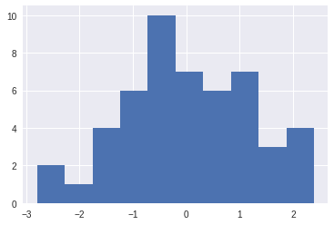

```python
np.random.seed(123)

data = np.random.randn(50)
plt.hist(data, bins=10);
```

Goal is to find the posterior distribution of the mean $\mu$ (assuming we know standard deviation $\sigma$ is 1)

### Simplified Markov Chain Monte Carlo

1. Start at arbitrary value for $\mu$
2. Select a new proposed value for $\mu$ by simply picking from a Normal distribution centred around the current $\mu$ value with $\sigma$ being the proposal width
3. Evaluate whether the probability of the proposed value explains the data $x$ better than the current value (see below for details)
4. If the proposed value is better, we move to it. If not, we still sometimes want to move to it (even though it's worse) so we can get a posterior distribution. The acceptance probability to move is given by:

$$\frac{P(\mu_{prop}|x)}{P(\mu_{curr}|x)} = \frac{\frac{P(x|\mu_{prop}) P(\mu_{prop})}{P(x)}}{\frac{P(x|\mu_{curr}) P(\mu_{curr})}{P(x)}} = \frac{P(x|\mu_{prop}) P(\mu_{prop})}{P(x|\mu_{curr}) P(\mu_{curr})}$$

```python
SAMPLES = 1000
PROPOSAL_WIDTH = 0.5

# Step 1: Set up current value
mu_curr = 1.0
trace = [mu_curr]

for i in range(SAMPLES):

    # Step 2: Select new proposed value
    mu_prop = norm(mu_curr, PROPOSAL_WIDTH).rvs()

    # Step 3: Evaluate fit to data
    likelihood_curr = norm(mu_curr, 1).pdf(data).prod()
    likelihood_prop = norm(mu_prop, 1).pdf(data).prod()

    prior_curr = norm(0, 1).pdf(mu_curr)
    prior_prop = norm(0, 1).pdf(mu_prop)

    p_curr = likelihood_curr * prior_curr
    p_prop = likelihood_prop * prior_prop

    # Step 4: Move or stay
    p_accept = min(p_prop/p_curr, 1)

    if np.random.rand() < p_accept:
        mu_curr = mu_prop

    # Record onto trace
    trace.append(mu_curr)
```

The proposal width controls the step size. Too small and it will take a long time to explore the space. Too large and it will keep jumping around. A sampler is more efficient when the samples are independent from each other (low autocorrelation). A rule of thumb is to aim for 50% proposal rejection.

### Results

The generated trace represents samples taken from the posterior distribution. The longer the trace, the better the representation. Note it takes a few samples to "settle" into the distribution so it's common the burn them.

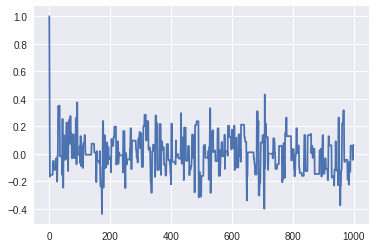

```python
plt.plot(trace);
```

Taking the histogram of the trace produces an approximation of the posterior distribution, i.e. our belief in what $\mu$ is

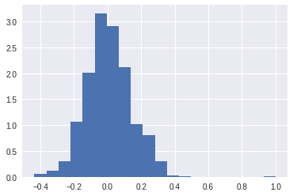

```python
plt.hist(trace, bins=20, density=True);
```

In this example we can get the exact posterior distribution analytically and can check how well it compares

```python
def calc_posterior_analytical(data, x, mu_0, sigma_0):
    sigma = 1.
    n = len(data)
    mu_post = (mu_0 / sigma_0**2 + data.sum() / sigma**2) / (1. / sigma_0**2 + n / sigma**2)
    sigma_post = (1. / sigma_0**2 + n / sigma**2)**-1
    return norm(mu_post, np.sqrt(sigma_post)).pdf(x)

x = np.linspace(-1, 1, 500)
posterior_analytical = calc_posterior_analytical(data, x, 0., 1.)
```

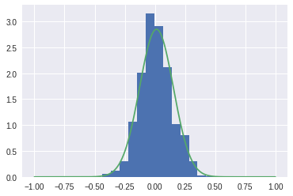

```python
plt.hist(trace, bins=20, density=True)
plt.plot(x, posterior_analytical)
plt.show();
```

Reference: https://twiecki.io/blog/2015/11/10/mcmc-sampling/

# PyMC3: Challenger Disaster

Patrick Ho

2019-03-24

```python
import pymc3 as pm
import theano.tensor as tt
import pandas as pd
import numpy as np
from scipy.stats.mstats import mquantiles
import matplotlib.pyplot as plt
plt.style.use('seaborn')

%matplotlib inline
```

### Load and prep data

```python
df = pd.read_csv('./data/challenger_data.csv')

df = df.drop(['Date'], axis=1)
df['Damage Incident'] = pd.to_numeric(df['Damage Incident'], errors='coerce')
df = df[df['Damage Incident'].notnull()]

print('Temp (F), O-Ring Failure?')
df
```

```
Temp (F), O-Ring Failure?
```

|  | Temperature | Damage Incident |
| --- | --- | --- |
| 0 | 66 | 0.0 |
| 1 | 70 | 1.0 |
| 2 | 69 | 0.0 |
| 4 | 68 | 0.0 |
| 5 | 67 | 0.0 |
| 6 | 72 | 0.0 |
| 7 | 73 | 0.0 |
| 8 | 70 | 0.0 |
| 9 | 57 | 1.0 |
| 10 | 63 | 1.0 |
| 11 | 70 | 1.0 |
| 12 | 78 | 0.0 |
| 13 | 67 | 0.0 |
| 14 | 53 | 1.0 |
| 15 | 67 | 0.0 |
| 16 | 75 | 0.0 |
| 17 | 70 | 0.0 |
| 18 | 81 | 0.0 |
| 19 | 76 | 0.0 |
| 20 | 79 | 0.0 |
| 21 | 75 | 1.0 |
| 22 | 76 | 0.0 |
| 23 | 58 | 1.0 |

### Define model

Explore the data and create a model for the actual underlying system

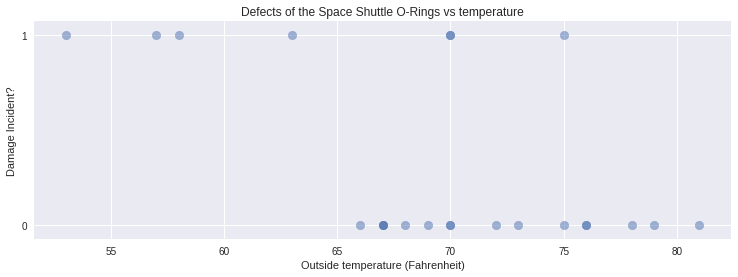

```python
plt.figure(figsize=(12.5, 4))

plt.scatter(df['Temperature'], df['Damage Incident'], s=75, alpha=0.5)
plt.yticks([0, 1])
plt.ylabel("Damage Incident?")
plt.xlabel("Outside temperature (Fahrenheit)")
plt.title("Defects of the Space Shuttle O-Rings vs temperature");
```

Damage incident appears to be more likely at lower temperatures.

Aim is to model probability of damage at different temperatures, $P(t)$. Can use the logistic function for this:

$$P(t)=\frac{1}{1+e^{-\beta t+\alpha}}$$

where $\beta$ controls the slope and $\alpha$ shifts curve left/right (bias)

```python
temperature = df['Temperature']
damaged = df['Damage Incident']

with pm.Model() as model:

    # Priors
    # Init both to 0 so P(t) has a reasonable starting value at 0.5
    beta = pm.Normal('beta', mu=0, sd=1000, testval=0)
    alpha = pm.Normal('alpha', mu=0, sd=1000, testval=0)

    # P(t) assumed to follow logistic function
    # Use Theano exp() to build this as compute graph
    p = pm.Deterministic('p', 1.0/(1.0 + tt.exp(-beta*temperature + alpha)))

    # Observed
    obs = pm.Bernoulli('obs', p, observed=damaged)

    # Sample
    step = pm.Metropolis()
    trace = pm.sample(120000, step=step, start=start)
    burned_trace = trace[100000::2]
```

```
Multiprocess sampling (2 chains in 2 jobs)
CompoundStep
>Metropolis: [alpha]
>Metropolis: [beta]
The estimated number of effective samples is smaller than 200 for some parameters.
```

```python
alpha_samples = burned_trace['alpha']
beta_samples = burned_trace['beta']
```

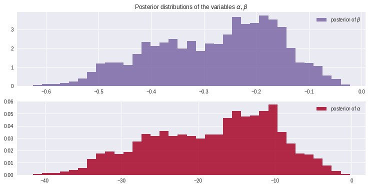

```python
plt.figure(figsize=(12.5, 6))

plt.subplot(211)
plt.title(r"Posterior distributions of the variables $\alpha, \beta$")
plt.hist(beta_samples, histtype='stepfilled', bins=35, alpha=0.85,
         label=r"posterior of $\beta$", color="#7A68A6", density=True)
plt.legend()

plt.subplot(212)
plt.hist(alpha_samples, histtype='stepfilled', bins=35, alpha=0.85,
         label=r"posterior of $\alpha$", color="#A60628", density=True)
plt.legend();
```

$\beta$ samples are <0:

- Does not centre around 0, which would have implied no effect (no slope)
- Negative means $P(t)$ increases as $t$ decreases

### Inspect model

```python
def logistic(x, beta=1, alpha=0):
    return 1.0 / (1.0 + np.exp(np.dot(-beta, x) + alpha))
```

```python
t_min = temperature.min()-5
t_max = temperature.max()+5
t_step = t_max-t_min+1

# Reshape from arrays to 1-D matrices to enable vector maths
t = np.linspace(t_min, t_max, t_step).reshape(-1,1)
beta_samples_1d = beta_samples.reshape(-1,1)
alpha_samples_1d = alpha_samples.reshape(-1,1)

print(beta_samples_1d.shape, t.T.shape, alpha_samples_1d.shape)

p_t = logistic(t.T, beta_samples_1d, alpha_samples_1d)

print(p_t.shape)

mean_p_t = p_t.mean(axis=0)
```

```
(20000, 1) (1, 39) (20000, 1)
(20000, 39)
```

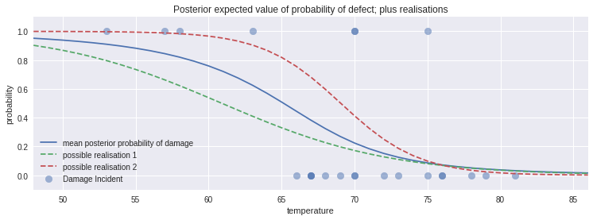

```python
plt.figure(figsize=(12.5, 4))

# Observed points
plt.scatter(temperature, damaged, s=75, alpha=0.5)

# Mean posterior
plt.plot(t, mean_p_t, label='mean posterior probability of damage')

# A couple of possible realisations from the posterior
plt.plot(t, p_t[0,:], ls='--', label='possible realisation 1')
plt.plot(t, p_t[-1,:], ls='--', label='possible realisation 2')

# Formatting
plt.xlim(t.min(), t.max())
plt.xlabel("temperature")
plt.ylim(-0.1, 1.1)
plt.ylabel("probability")
plt.legend(loc="lower left")
plt.title("Posterior expected value of probability of defect; \
plus realisations");
```

The dotted lines are just possible realisations of what the actual underlying system might be and are equally likely as any other draw. The solid line is the average of all 20000 possible dotted lines together.

##### 95% Credible Intervals

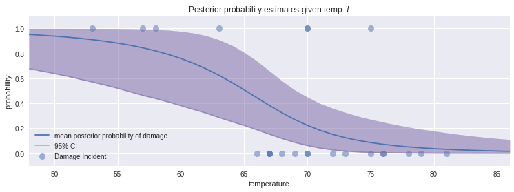

```python
plt.figure(figsize=(12.5, 4))

# Observed points
plt.scatter(temperature, damaged, s=75, alpha=0.5)

# Mean posterior
plt.plot(t, mean_p_t, label='mean posterior probability of damage')

# 95% Credible Interval
qs = mquantiles(p_t, [0.025, 0.975], axis=0)
plt.fill_between(t.reshape(-1), y1=qs[0], y2=qs[1],
                 color="#7A68A6", alpha=0.5)
plt.plot(t.reshape(-1), qs[0], label="95% CI",
         color="#7A68A6", alpha=0.5)

# Formatting
plt.xlim(t.min(), t.max())
plt.xlabel("temperature")
plt.ylim(-0.1, 1.1)
plt.ylabel("probability")
plt.legend(loc="lower left")
plt.title('Posterior probability estimates given temp. $t$');
```

Credible interval is widest around 60-65 degrees so we are most uncertain about the estimates here. Suggest gathering more data around here to improve estimates.

##### Day of Challenger disaster

Temperature was 31 degrees F. Under these conditions the model suggests that damage was almost guaranteed.

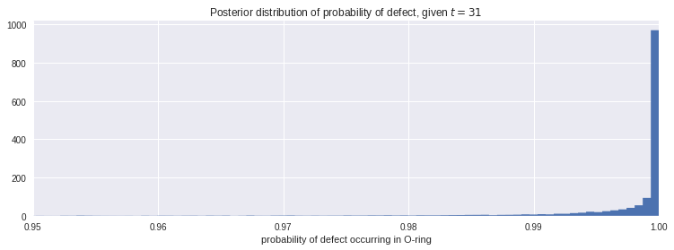

```python
plt.figure(figsize=(12.5, 4))

prob_31 = logistic(31, beta_samples, alpha_samples)

plt.xlim(0.95, 1)
plt.hist(prob_31, bins=1000, density=True, histtype='stepfilled')
plt.title("Posterior distribution of probability of defect, given $t = 31$")
plt.xlabel("probability of defect occurring in O-ring");
```

Reference: https://github.com/CamDavidsonPilon/Probabilistic-Programming-and-Bayesian-Methods-for-Hackers

# Bayesian A/B Testing

Patrick Ho

2019-03-24

```python
from scipy.stats import beta
from scipy.optimize import fmin
from scipy.special import betaln
import numpy as np
```

### Setup

```python
# Set up
RANDOM_SEED = 888
SIM_SIZE = 100000
CI_PROB = 0.95

success_a = 100
total_a = 250
success_b = 130
total_b = 300
```

```python
# Success rates
rate_a = success_a / total_a
rate_b = success_b / total_b

print(rate_a, rate_b, rate_b-rate_a)
```

```
0.4 0.43333333333333335 0.033333333333333326
```

```python
# Alpha/Beta parameters
alpha_a = success_a + 1
beta_a = total_a - success_a + 1
alpha_b = success_b + 1
beta_b = total_b - success_b + 1

print(alpha_a, beta_a, alpha_b, beta_b)
```

```
101 151 131 171
```

### Highest (Posterior) Density Intervals

Narrowest interval that captures the 95% of values that are most likely to occur

```python
# Find Highest Density Interval from an Inverse Cumulative Distribution Function
# Adapted from: Doing Bayesian Data Analysis by John K. Kruschke
def hdi_from_icdf(dist_name, ci_prob, **args):

    dist = dist_name(**args)

    def interval_width(low_prob):
        return dist.ppf(low_prob+ci_prob) - dist.ppf(low_prob)

    initial_guess = 1.0 - ci_prob
    ci_low_prob = fmin(interval_width, initial_guess, ftol=1e-8, disp=False)[0]

    return dist.ppf([ci_low_prob, ci_low_prob+ci_prob])
```

```python
# HDI for A and B
hdi_a = hdi_from_icdf(beta, ci_prob=CI_PROB, a=alpha_a, b=beta_a)
hdi_b = hdi_from_icdf(beta, ci_prob=CI_PROB, a=alpha_b, b=beta_b)

print(hdi_a, hdi_b)
```

```
[0.34068584 0.46133168] [0.37814769 0.48966612]
```

```python
# Find Highest Density Interval from a sample
# Check all 95% widths and pick the one that is smallest
def hdi_from_values(sample, ci_prob):

    sorted_sample = np.sort(sample)

    sample_size = len(sorted_sample)
    ci_size = min(int(np.ceil(sample_size*0.95)), sample_size-1)

    num_ci = sample_size - ci_size
    ci_widths = np.repeat(0.0, num_ci)
    for i in range(num_ci):
        ci_widths[i] = sorted_sample[i+ci_size] - sorted_sample[i]

    hdi_low = sorted_sample[ci_widths.argmin()]
    hdi_upp = sorted_sample[ci_widths.argmin() + ci_size]

    return [hdi_low, hdi_upp]
```

```python
# Simulate a sample of rate differences
diff_sample = beta.rvs(alpha_b, beta_b, size=SIM_SIZE, random_state=RANDOM_SEED) \
                - beta.rvs(alpha_a, beta_a, size=SIM_SIZE, random_state=RANDOM_SEED)
```

```python
# HDI for Diff
hdi_from_values(diff_sample, ci_prob=CI_PROB)
```

```
[-0.040244199794189195, 0.10915908544664593]
```

### Probability that B is better than A

```python
# Probability that B is better than A
# http://www.evanmiller.org/bayesian-ab-testing.html#binary_ab
def prob_b_beats_a(alpha_a, beta_a, alpha_b, beta_b):
    prob = 1.0
    for i in range(alpha_a):
        prob -= np.exp(betaln(alpha_b+i, beta_b+beta_a) \
                        - np.log(beta_a+i) - betaln(1+i, beta_a) - betaln(alpha_b, beta_b))
    return prob
```

```python
prob_b_winner = prob_b_beats_a(alpha_a, beta_a, alpha_b, beta_b)
prob_b_winner
```

```
0.7840958578240851
```

```python
prob_a_winner = prob_b_beats_a(alpha_b, beta_b, alpha_a, beta_a)
prob_a_winner
```

```
0.21590414217575646
```

### Expected loss if we choose B but A is actually better

Call a winner when expected loss is below some defined threshold

```python
# Expected loss if choose B but A is actually better
# https://www.chrisstucchio.com/blog/2014/bayesian_ab_decision_rule.html

def expected_loss_b_over_a(alpha_a, beta_a, alpha_b, beta_b):
    exp_loss = np.exp(betaln(alpha_a+1, beta_a) - betaln(alpha_a, beta_a) \
                      + np.log(1-prob_b_beats_a(alpha_a+1, beta_a, alpha_b, beta_b))) \
             - np.exp(betaln(alpha_b+1, beta_b) - betaln(alpha_b, beta_b) \
                      + np.log(1-prob_b_beats_a(alpha_a, beta_a, alpha_b+1, beta_b)))
    return exp_loss
```

```python
exp_loss = expected_loss_b_over_a(alpha_a, beta_a, alpha_b, beta_b)
exp_loss
```

```
0.005185573911307043
```

```python
exp_uplift = expected_loss_b_over_a(alpha_b, beta_b, alpha_a, beta_a)
exp_uplift
```

```
0.03816675755479232
```

#### Alternative numerical method

```python
posteriorA = beta.cdf(np.linspace(0.0,0.99,100)+0.01, alpha_a, beta_a)-beta.cdf(np.linspace(0.0,0.99,100), alpha_a, beta_a)
posteriorB = beta.cdf(np.linspace(0.0,0.99,100)+0.01, alpha_b, beta_b)-beta.cdf(np.linspace(0.0,0.99,100), alpha_b, beta_b)
```

```python
joint_posterior = np.zeros([100,100])
```

```python
for i in range(100):
    for j in range(100):
        joint_posterior[i,j] = posteriorA[i] * posteriorB[j]
```

```python
# Probability we make a mistake by choosing A
errorFunctionA = 0.0
for i in range(100):
    for j in range(i, 100):
        errorFunctionA += joint_posterior[i,j]
errorFunctionA
```

```
0.8166749959983718
```

```python
# Probability we make a mistake by choosing B
errorFunctionB = 0.0
for i in range(100):
    for j in range(0, i):
        errorFunctionB += joint_posterior[i,j]
errorFunctionB
```

```
0.183325004001625
```

```python
def loss(i, j, var):
    if var=='A':
        return max(j*0.01 - i*0.01, 0.0)
    if var=='B':
        return max(i*0.01 - j*0.01, 0.0)
```

```python
# Expected loss for choosing B and we're wrong
lossFunction = 0.0
for i in range(100):
    for j in range(100):
        lossFunction += joint_posterior[i,j] * loss(i,j,'B')
lossFunction
```

```
0.005185573911297853
```

```python
# Expected loss for choosing A and we're wrong
lossFunction = 0.0
for i in range(100):
    for j in range(100):
        lossFunction += joint_posterior[i,j] * loss(i,j,'A')
lossFunction
```

```
0.038166757554733005
```

# fastai: Image Classification

Patrick Ho

2018-08-14

## Image Classification: Cats and Dogs

1. Load up a pre-trained model and set `precompute=True`
2. Use `lr_find()` to find learning rate
3. Train last layer from precomputed activations for 1-2 epochs
4. Train last layer with data augmention (must set `precompute=False`) for 2-3 epochs with `cycle_len=1`
5. Unfreeze all layers
6. Set earlier layers to 3x-10x lower learning rate than next higher layer
7. Use `lr_find()` to find new learning rate
8. Train full network with `cycle_mult=2` until overfitting

### Setup

```python
from fastai.imports import *

from fastai.transforms import *
from fastai.conv_learner import *
from fastai.model import *
from fastai.dataset import *
from fastai.sgdr import *
from fastai.plots import *
```

```python
# Check if Nvidia GPU is set up and CUDA is available
torch.cuda.is_available()
```

```
True
```

```python
# Check if specialised Neural Network (CUDNN) features are enabled
torch.backends.cudnn.enabled
```

```
True
```

### Data

Images of cats and dogs organised by folders:

- 23000 train (11500 in /train/cats/, 11500 in /train/dogs/)
- 2000 validation (1000 in /valid/cats/, 1000 in /valid/dogs/)
- 12500 test (in /test1/)

```python
# Set path to images
PATH = "./data/dogscats"
```

```python
# List of 5 dog pictures in validation folder
files = os.listdir(PATH + '/valid/dogs')[:5]
files
```

```
['dog.2851.jpg',
 'dog.8500.jpg',
 'dog.7275.jpg',
 'dog.6665.jpg',
 'dog.1150.jpg']
```

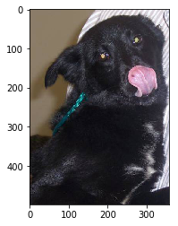

```python
# Show example image
img = plt.imread(PATH + '/valid/dogs/' + files[0])
plt.imshow(img);
```

```python
# Image dimensions - height, width, colours (RGB)
img.shape
```

```
(499, 357, 3)
```

```python
# Image raw data - RGB values for top left 3x3 pixels
img[:3, :3]
```

```
array([[[137, 122, 103],
        [137, 122, 103],
        [138, 123, 104]],

       [[137, 122, 103],
        [137, 122, 103],
        [138, 123, 104]],

       [[137, 122, 103],
        [137, 122, 103],
        [138, 123, 104]]], dtype=uint8)
```

### Initial Fit with Pre-trained Model

Use a pre-trained model from a similar problem to get a head start on training by taking advantage of what it has already learned from other images. Using different architectures may yield better results, e.g. resnext50 instead of resnet34.

##### Pre-Compute

The *activations* at the second last layer (just before classification) of an image recognition model indicate that certain features (e.g. an eye, an ear, a paw) have been detected at various locations in the image with some level of confidence.

Setting `precompute = True` will save the activations of every image so they don't need to be computed every time. This makes subsequent fitting runs faster.

Precomputed activations are saved in the `tmp` directory. If there were issues creating these, delete the files to start fresh again.

##### Image Pre-Processing

Different models require different pre-processing that needs to be applied on the images like normalisation. `tfms_from_model()` defines the appropriate pre-processing to use for the given model. If using an ImageNet model (like resnet34), note that most are trained on images that are around 224x224 or 299x299.

Start with small image sizes for faster training initially for a few epochs. If your images are similar to the pre-trained model images, be careful not to go *too* small as to destroy the weights. But if images are more different, safer to go smaller.

Can then use `learn.set_data()` to switch to larger images and continue training - effective way to avoid overfitting as we're using different images. If your image/batch sizes cause a CUDA out of memory error, then restart kernel and use smaller batch size.

##### ImageClassifierData

Use `from_paths()` if images are organised into train/valid/test by folder. Use `from_csv()` if image labels are in a CSV lookup file - need to randomly select indexes for our validation set.

Access the image file paths for the training and validation sets with `data.trn_ds.fnames[index]` and `data.val_ds.fnames[index]`

##### Learner

`ConvLearner.pretrained()` builds a *learner* that contains a pre-trained model with the last layer replaced by the right dimensions.

E.g. ImageNet models predict 1000 classes, so the final layer has 1000 neurons outputting probabilities for each class. In this case, that is replaced by just 2 neurons for Cats and Dogs.

```python
# Use resnet34 which was 2015 winner of ImageNet competition
arch = resnet34

# Resize images to this size
sz = 224

# Read in images and assign their labels based on folder names
data = ImageClassifierData.from_paths(PATH, tfms=tfms_from_model(arch, sz))

# Create learner
learn = ConvLearner.pretrained(arch, data, precompute=True)
```

#### Choose Learning Rate

Find learning rate using technique from [Cyclical Learning Rates for Training Neural Networks](http://arxiv.org/abs/1506.01186)

Note that different optimiser algorithms will require different learning rates, so need to `lr_find()` again if changing optimiser.

```python
lrf = learn.lr_find()
```

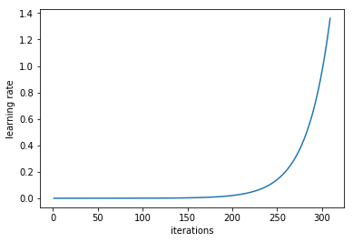

```python
# Plot learning rate used at each iteration (SGD mini-batch)
learn.sched.plot_lr()
```

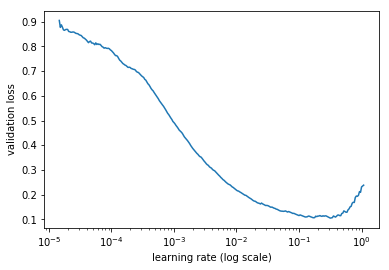

```python
# Plot loss as learning rate increases
learn.sched.plot()
```

Pick highest learning rate where loss is still decreasing, e.g. find point that's lowest (1e-1) and go back an order of magnitude (1e-2).

#### Initial Fit

Use the learning rate that we've just found to train the last layer from precomputed activations.

```python
learn.fit(0.01, 2)
```

```
epoch      trn_loss   val_loss   accuracy
    0      0.051373   0.029799   0.988
    1      0.052693   0.029384   0.9905
```

```
[array([0.02938]), 0.9905]
```

### Fit Model with Data Augmentations and SGDR

#### Define Data Augmentations

To reduce overfitting, create more data through *data augmentation* - randomly change the images in ways that don't change their interpretation like flipping, zooming, and rotating.

`aug_tfms` is the list of augmentation transforms. For side-on images (as opposed to top-down) we can use the pre-defined `transforms_side_on` list.

Augmentations are defined alongside the pre-processing rules in `tfms_from_model()` as they're all transformations of the data needed for modelling.

Idea: Increase image sizes by adding a reflected border (padding)

```python
transforms_side_on
```

```
[<fastai.transforms.RandomRotate at 0x7fd0bf0cf278>,
 <fastai.transforms.RandomLighting at 0x7fd0bf0cf2e8>,
 <fastai.transforms.RandomFlip at 0x7fd0bf0cf320>]
```

```python
# Define transformations to apply
tfms = tfms_from_model(arch, sz, aug_tfms=transforms_side_on, max_zoom=1.1)
```

##### Example: Show Augmented Images

```python
def get_augs():
    data = ImageClassifierData.from_paths(PATH, bs=2, tfms=tfms, num_workers=1)
    x,_ = next(iter(data.aug_dl))
    return data.trn_ds.denorm(x)[1]
```

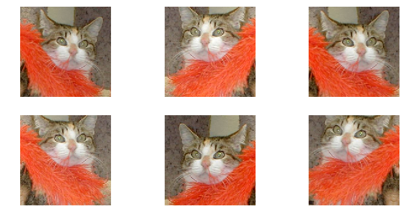

```python
ims = np.stack([get_augs() for i in range(6)])
plots(ims, rows=2)
```

#### Fit Model

We can't use `precompute=True` as we need new activations calculated for the augmented images. Each epoch, we use a slightly different version of the images for training.

##### Stochastic Gradient Descent with Restarts (SGDR)

This is a variant of *learning rate annealing* which decreases the learning rate as training progresses so we take smaller steps closer to the minima. One approach for reducing the step size is *cosine annealing* named after the first part of the cosine curve.

Some areas of the loss space may be 'spikey' where a small step (small change in weights) can cause a big change in loss. Occasionally *restarting* the learning rate to a higher value again will help jump to somewhere less 'spikey' and hopefully find a more stable/'flatter' area. These areas suggest better generalisation because there is less variance in loss for slightly different weights.

`cycle_len` defines how many epochs to go through before restarting.

```python
data = ImageClassifierData.from_paths(PATH, tfms=tfms)
learn = ConvLearner.pretrained(arch, data, precompute=False)
```

```python
learn.fit(1e-2, n_cycle=3, cycle_len=1)
```

```
epoch      trn_loss   val_loss   accuracy
    0      0.064771   0.033516   0.9885
    1      0.054377   0.026298   0.99
    2      0.040428   0.025494   0.991
```

```
[array([0.02549]), 0.991]
```

Results show accuracy not getting better but at least we're not overfitting (where training loss would appear much lower than validation loss).

`val_loss` is lower than `trn_loss` though, so might be underfitting. `cycle_len` might not be long enough for it to find minima, so we can use `cycle_mult` to give it more time (see below)

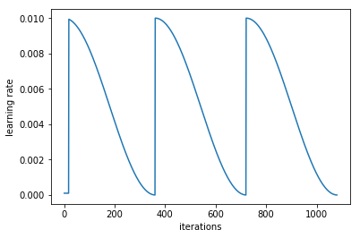

```python
# Plot learning rates used in SGDR
learn.sched.plot_lr()

# Notice 3 cycles of cosine annealing with cycle reset occurring after 1 epoch
```

Possible to generalise even better through *Snapshot Ensembling* by saving weights at end of each cycle and taking average of predictions. Can set `cycle_save_name` to save these sets of weights.

```python
# Save model to 'models' folder
learn.save('224_lastlayer')
```

```python
# Load model from 'models' folder
learn.load('224_lastlayer')
```

### Fine Tune Other Layers with Differential Learning Rates and Cycle Length Multipying

Up to this point, we have only trained the final layer. Now we can `unfreeze()` and try to fine tune the other layers for better performance.

##### Differential Learning Rates

The other layers contain carefully tuned weights trained on ImageNet that we don't want to completely wipe away. Earlier layers generally pick up more general-purpose features, so we shouldn't need to alter them as much. We can use *differential learning rates* to account for this - smaller learning rates for earlier layers and larger rates for later layers.

Rule of thumb: Scale learning rates down by 10x each time if the pre-trained model images are similar to your current images. Scale by 3x each time if images are more different.

##### Cycle Length Multiplying

Short cycle lengths have more difficulty finding optimum point as the restarts may causes it to 'pop out' before it can get there. Initially this is useful behaviour to quickly find a good general area, but we gradually want to increase the time spent exploring for the optimum point as we get closer.

`cycle_mult` multiples the `cycle_len` after each cycle completes so that each they get longer and longer.

```python
# Unfreeze all layers
learn.unfreeze()
```

```python
# Learning rates for beginning, middle, and final layers (grouped in blocks)
diff_lrs=np.array([1e-4, 1e-3, 1e-2])
```

```python
learn.fit(diff_lrs, n_cycle=3, cycle_len=1, cycle_mult=2)
```

```
epoch      trn_loss   val_loss   accuracy
    0      0.048321   0.027019   0.9905
    1      0.037094   0.021331   0.992
    2      0.043817   0.019246   0.993
    3      0.027186   0.020452   0.9905
    4      0.025177   0.019603   0.992
    5      0.028295   0.018593   0.992
    6      0.017249   0.018516   0.9925
```

```
[array([0.01852]), 0.9925]
```

Results show better accuracy than before. `trn_loss` and `val_loss` end up similar so we're not over/underfitting.

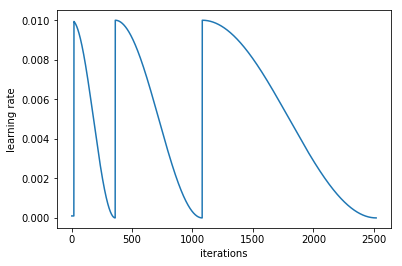

```python
# Plot learning rates - Plots rate of last layer if using differential rates
learn.sched.plot_lr()

# Notice 3 cycles of 1, 2, then 4 epochs = Total 7 epochs
```

```python
# Save model to 'models' folder
learn.save('224_all')
```

```python
# Load model from 'models' folder
learn.load('224_all')
```